# Explanatory Data Analysis on HR Data

Let’s have a look at departmentwise job satisfaction level of the employees.

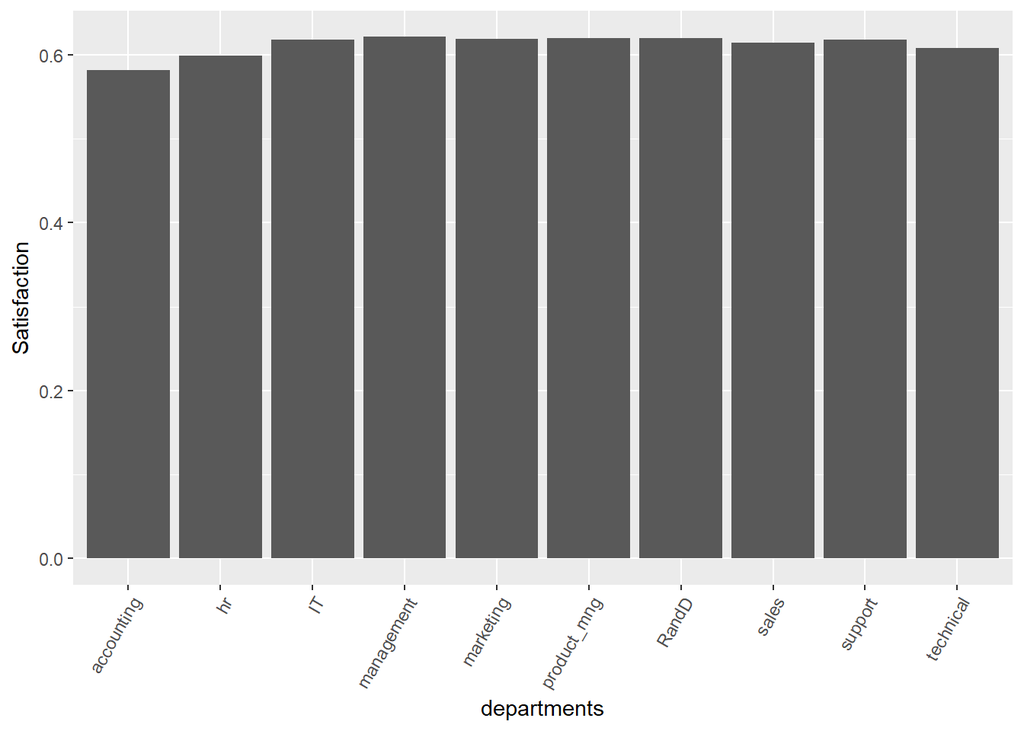

```r
 dep_satis <- d %>%
  group_by(departments) %>%
  summarise (Satisfaction =mean(satisfaction_level))
  ggplot(data=dep_satis, aes(x=departments, y=Satisfaction)) +
  theme(axis.text.x = element_text(angle = 60, hjust=1))+
  geom_bar(stat="identity", position=position_dodge())
```

It appears that the level of satisfaction is pretty much the same for all the departments except for some unhappy folks in the accounting department. While rest of the departments average satisfaction value is around 60% (which comply with overall satisfaction rate of 61.28%), accounting department’s mean is below the company’s mean. May be we should focus to that department seperately.

```r
department_left_rate<-d %>%
  group_by(departments) %>%
  summarise (n = n()) %>%
  mutate(freq = n / sum(n))

department_left_rate
```

```
## # A tibble: 10 x 3
##    departments     n       freq
##         <fctr> <int>      <dbl>
##  1  accounting   767 0.05113674
##  2          hr   739 0.04926995
##  3          IT  1227 0.08180545
##  4  management   630 0.04200280
##  5   marketing   858 0.05720381
##  6 product_mng   902 0.06013734
##  7       RandD   787 0.05247016
##  8       sales  4140 0.27601840
##  9     support  2229 0.14860991
## 10   technical  2720 0.18134542
```

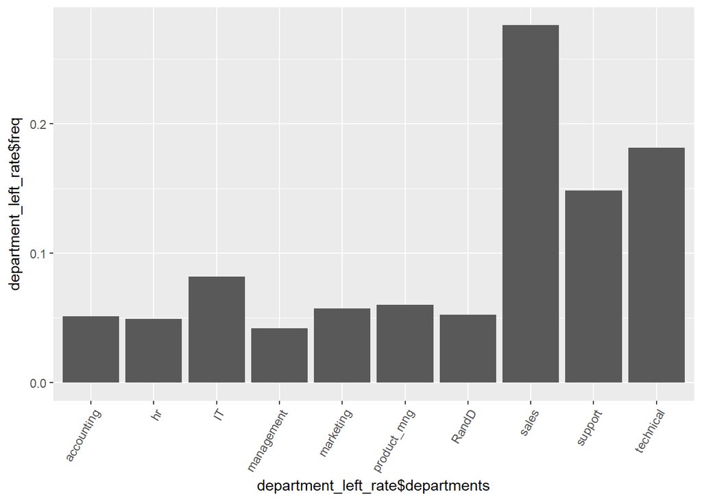

```r
ggplot(department_left_rate, aes(x=department_left_rate$departments,y=department_left_rate$freq ))+
      theme(axis.text.x = element_text(angle = 60, hjust=1))+
      geom_bar(stat = "identity")
```

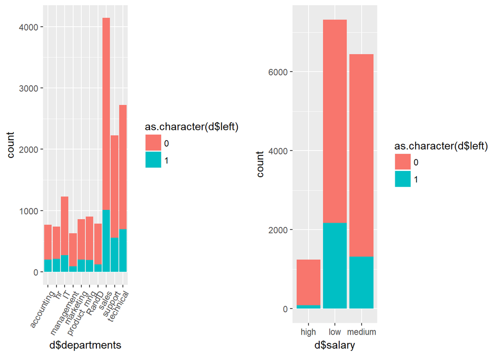

```r
p9 <- ggplot(d, aes(x=d$departments,fill=as.character(d$left) ))+
  theme(axis.text.x = element_text(angle = 60, hjust=1))+
  geom_bar()

p10 <- ggplot(d, aes(x=d$salary,fill=as.character(d$left) ))+
      geom_bar()
#ggtitle("Average bill for 2 people")

multiplot(p9,p10,cols=2)
```